# 5.1. Clusters Exploratory Analysis

Alexander Sheludkov

26 11 2018

```r
library(sp)
library(sf)
library(dplyr)
```

```r
library(tidyr)
library(ggplot2)
library(ggforce)
library(stringr)
```

```r
load(file = "data/Part3_res_dataset.Rdata")
load("data/settlements.Rdata")
```

## Сжатие расселения на уровне кластеров

### 1. Как изменилась территориальная дифференциация расселения с 2002 по 2010 гг.?

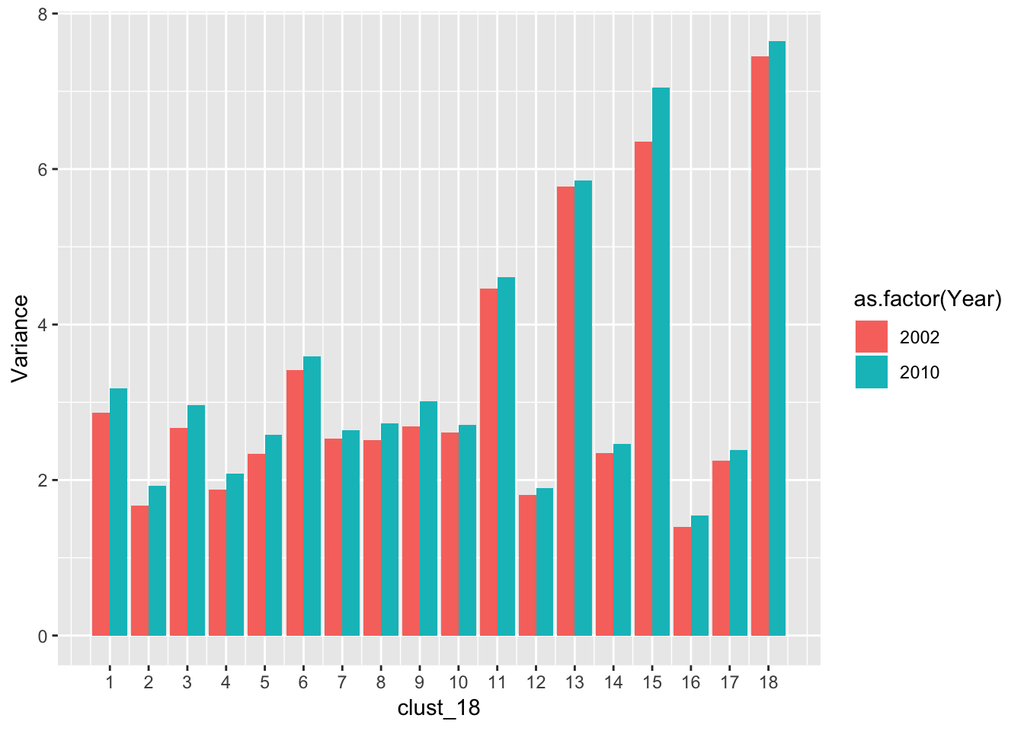

```r
clusters_18_metrics %>%
  select(clust_18, CL18_variance_2002, CL18_variance_2010) %>%
  gather(Year, Variance, CL18_variance_2002:CL18_variance_2010) %>%
  mutate(Year = as.integer(str_extract(Year, "\\d{4}"))) %>%
  ggplot(aes(x = clust_18, y = Variance, fill = as.factor(Year)))+
  geom_col(position = position_dodge())+
  scale_x_continuous(breaks = 1:18)
```

Вывод 1: во всех кластерах территориальная дифференциация расселения увеличилась (то есть расселение сжималось)

### 2. Существуют ли пространственные закономерности в распределении показателя вариации?

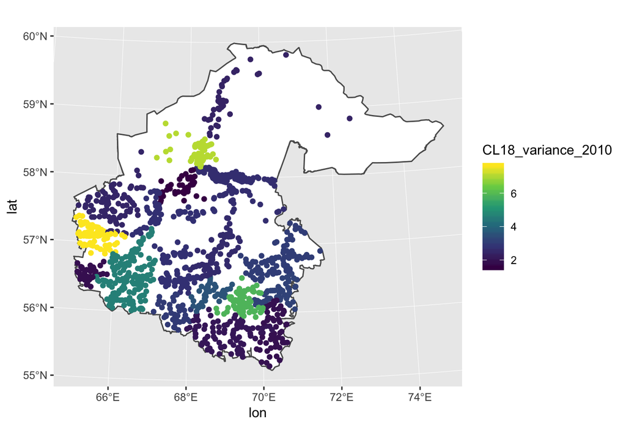

```r
ggplot()+
  geom_sf(data = st_as_sf(region), fill = "white")+
  geom_point(data = df, aes(x = lon, y = lat, col = CL18_variance_2010))+
  # geom_raster(data = df, aes(x = lon, y = lat, fill = CL18_variance_2010))+
  scale_color_viridis_c()
```

Самая высокая дифференциация расселения у кластеров вокруг городов (Тюмень, Тобольск, Ишим), далее идут 11 кластер (Ялуторовск, Заводоуковск, Упорово), затем Голышманово и Викулово+Сорокино. Самые низкие показатели вариации - в Исетском районе, а также на ЮВ - в Казанском, Бердюжском, Сладковском и Абатском районах + в бывшем Байкаловском районе.

### 3. Существуют ли пространственные закономерности в темпах сжатия расселения?

Да, более восточные (за исключением Ишимског района) и северные (за исключением Уватского и Вагайского районов) сжимаются быстрее. Кроме того, на карте явно выделяется субширотная транспортная ось - районы вдоль нее - Омутинский, Голышмановский, Ишимский - сжимаются медленне, районы в стороне от оси, как к северу, так и к югу - быстрее.

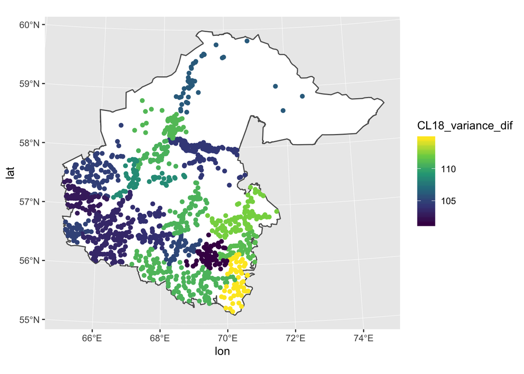

```r
ggplot()+
  geom_sf(data = st_as_sf(region), fill = "white")+
  geom_point(data = df, aes(x = lon, y = lat, col = CL18_variance_dif))+
  # geom_raster(data = df, aes(x = lon, y = lat, fill = CL18_variance_2010))+
  scale_color_viridis_c()
```

### 4. Как сжатие расселения соотносится с изменением численности населения кластеров?

Рост численности населения формирует обратный сжатию расселения пространственный градиент

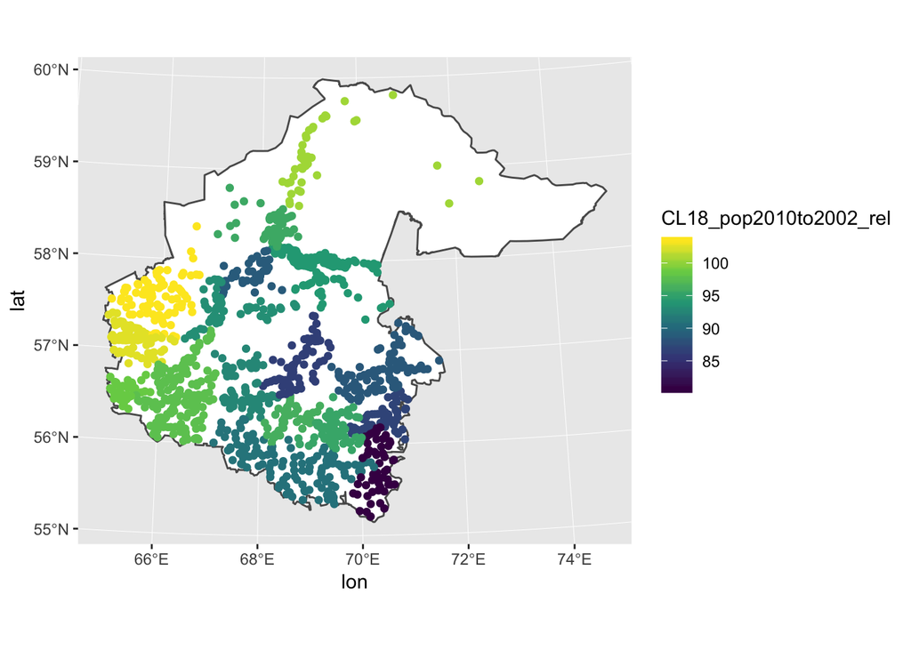

```r
ggplot()+
  geom_sf(data = st_as_sf(region), fill = "white")+
  geom_point(data = df, aes(x = lon, y = lat, col = CL18_pop2010to2002_rel))+
  # geom_raster(data = df, aes(x = lon, y = lat, fill = CL18_pop2010to2002_rel))+
  scale_color_viridis_c()
```

По интенсивности депопуляции и сжатия расселения кластеры разибваются на две примерно равные группы. В ситуации роста или слабой депопуляции (A) контрастность расселения растет медленно. Сокращение населения (Б), напротив, сопровождается интенсивным сжатием расселения в пределах кластеров; таким образом, крупные н.п. становятся относительно крупнее, мелкие - относительно мельче, а кластер в целом - более территориально дифференцированным.

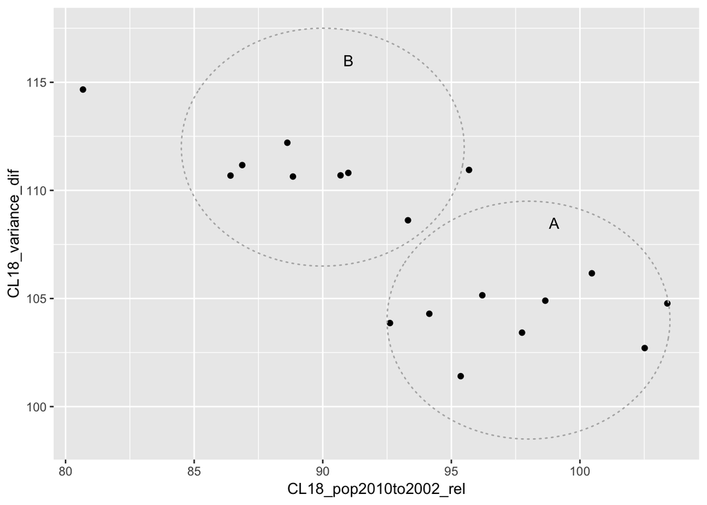

```r
clusters_18_metrics %>%
  ggplot(aes(x = CL18_pop2010to2002_rel, y = CL18_variance_dif))+
  geom_point()+
  geom_circle(data = data_frame(x = c(90, 98), y = c(112, 104)),
              mapping = aes(x0 = x, y0 = y, r = 5.5),
              color = "grey70",linetype = "dotted",  alpha = 1,
              inherit.aes = F)+
  annotate("text", x = 99, y = 108.5, label = "A")+
  annotate("text", x = 91, y = 116, label = "B")
```

### 5. Различаются ли кластеры по плотности (density) графов и влияла ли плотность на темпы сжатия расселения?

Различия между районами есть

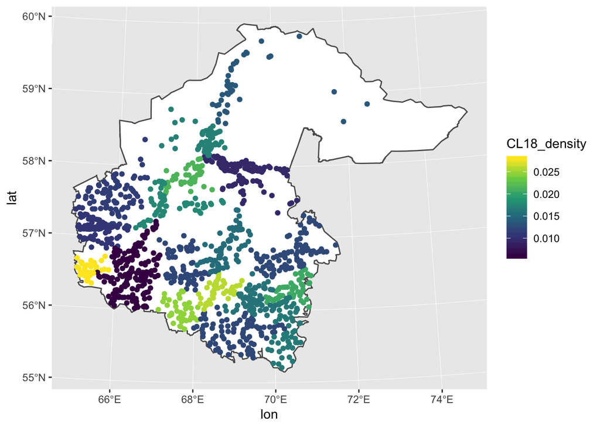

```r
df %>%
  ggplot()+
  geom_sf(data = st_as_sf(region), fill = "white")+
  geom_point(aes(x = lon, y = lat, col = CL18_density))+
  scale_color_viridis_c()
```

Чем выше плотность графа, тем сильнее сжатие сети (?).

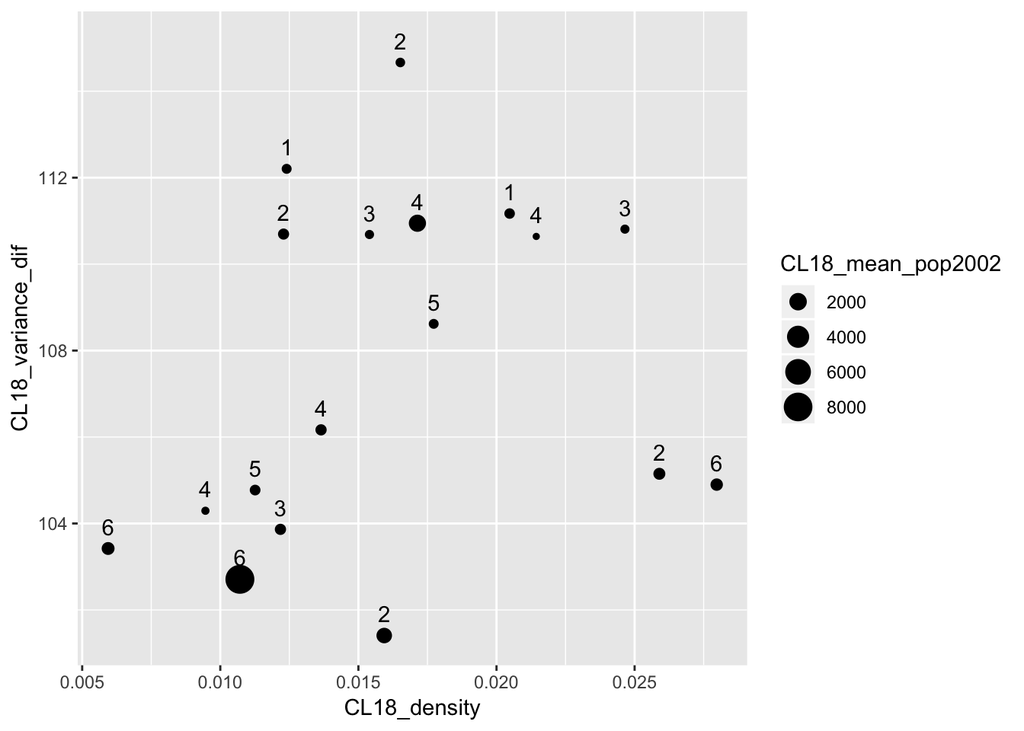

```r
clusters_18_metrics %>%
  ggplot(aes(x = CL18_density, y = CL18_variance_dif))+
  # geom_smooth()+
  geom_point(aes(size = CL18_mean_pop2002))+
  geom_text(aes(x = CL18_density, y = CL18_variance_dif + 0.5,  label = clust_6))
```

А как насчет связи плотности сети и общей динамики населения?

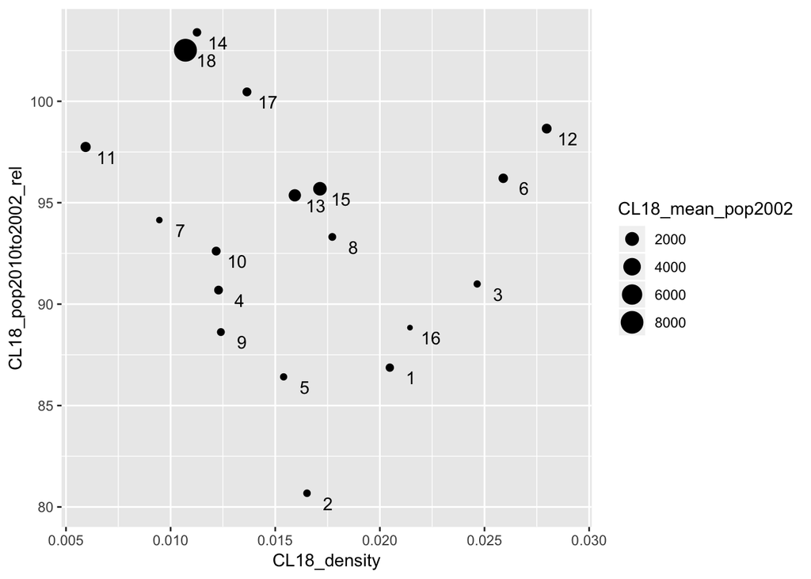

```r
clusters_18_metrics %>%
  ggplot(aes(x = CL18_density, y = CL18_pop2010to2002_rel))+
  geom_point(aes(size = CL18_mean_pop2002))+
  # geom_smooth(col = "grey")+
  geom_text(aes(x = CL18_density+0.001, y = CL18_pop2010to2002_rel - 0.5, label = clust_18))
```

Мораль, видимо, в том, что показатель плотности графа обратно пропорционален числу н.п., входящих в граф. В итоге, крупные кластеры, например 11, получили низкое значение плотности.

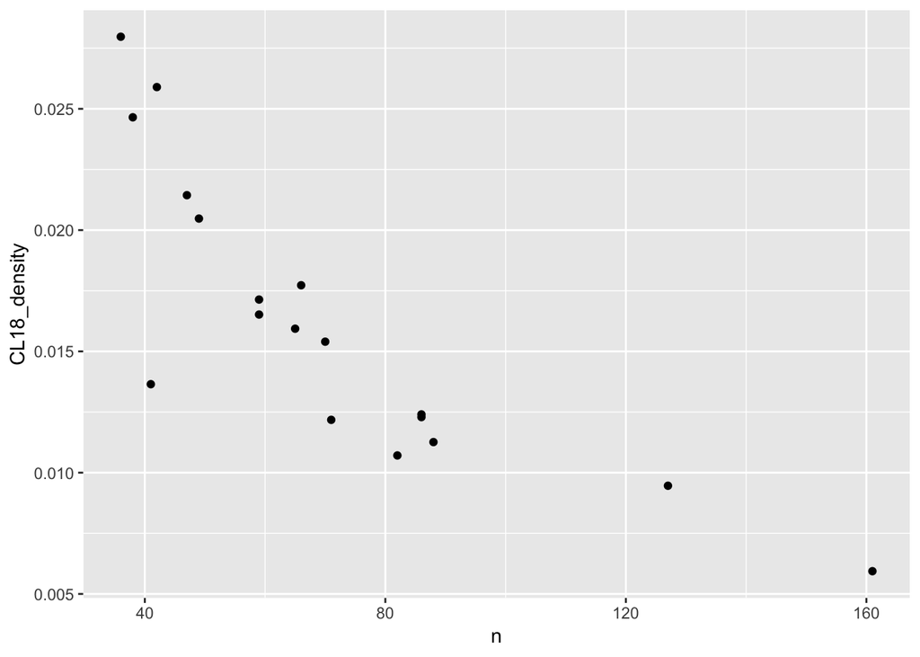

```r
df %>%
  group_by(clust_18) %>%
  summarise(n = n()) %>%
  left_join(clusters_18_metrics, by = c("clust_18")) %>%
  ggplot()+
  geom_point(aes(x = n, y = CL18_density))
```

Вопрос: есть ли смысл использовать этот показатель далее или следует его заменить?

### 6. Как различается медианная длина пути между н.п. в кластерах?

В качестве альтернативы density можно использовать медианну пути между н.п. в кластерах. Она также показывает, насколько “плотно” расположены н.п., но проще интерпретируема.

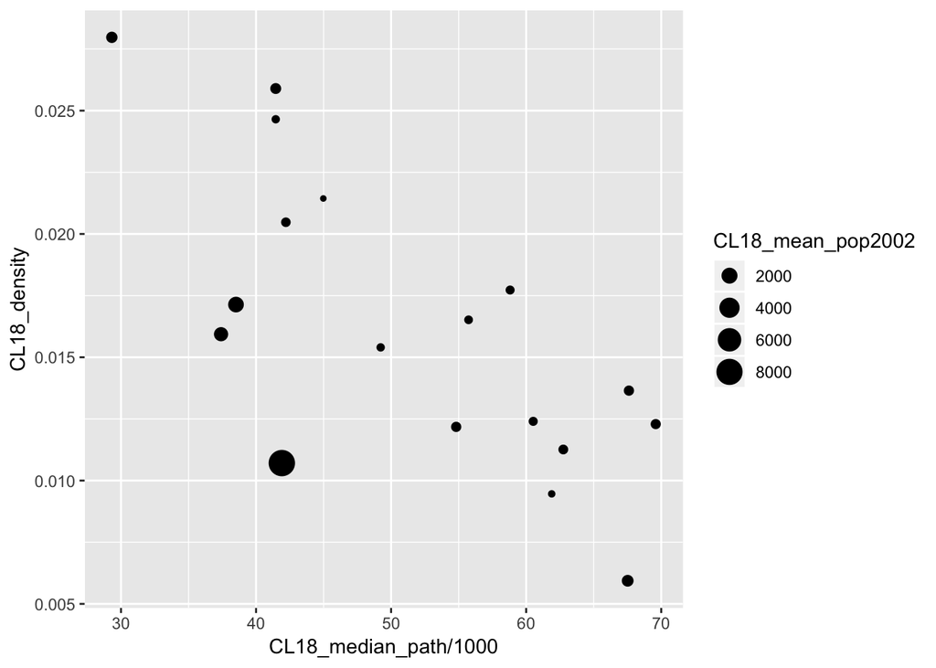

```r
clusters_18_metrics %>%
  ggplot(aes(x = CL18_median_path/1000, y = CL18_density))+
  # geom_smooth()+
  geom_point(aes(size = CL18_mean_pop2002))
```

```r
# Корреляция
cor(clusters_18_metrics$CL18_density, clusters_18_metrics$CL18_median_path)
```

```
## [1] -0.7303862
```

Существуют ли пространственные закономерности в распределении показателя между кластерами?

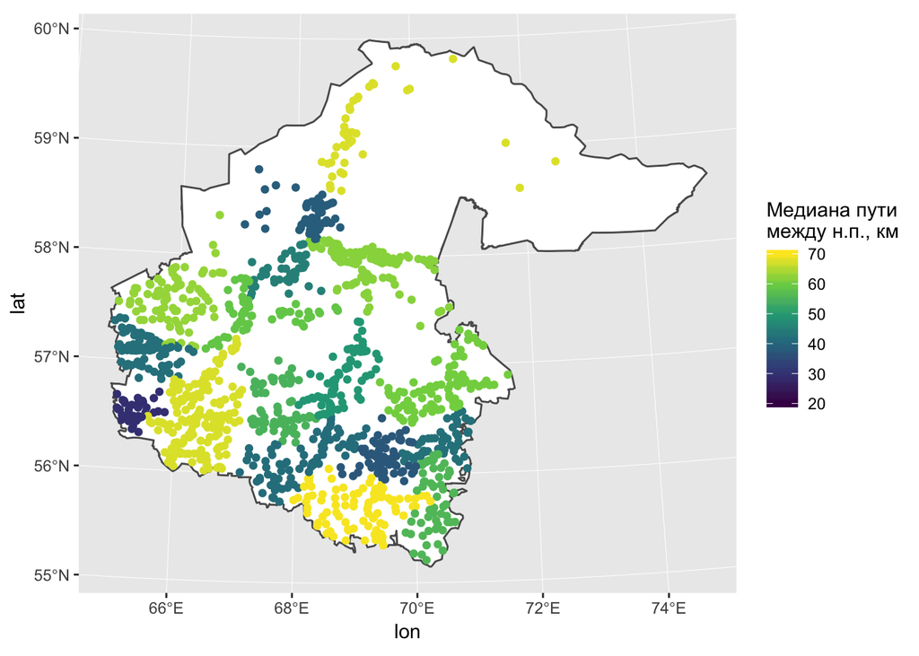

```r
df %>%
  ggplot()+
  geom_sf(data = st_as_sf(region), fill = "white")+
  geom_point(aes(x = lon, y = lat, col = CL18_median_path/1000))+
  scale_color_viridis_c(name = "Медиана пути\nмежду н.п., км",
                        limits = c(20, 70),
                        breaks = seq(20,70, 10))
```

Пространственный закономерностей нет.

Есть ли связь между медианной длиной пути и сжатием расселения?

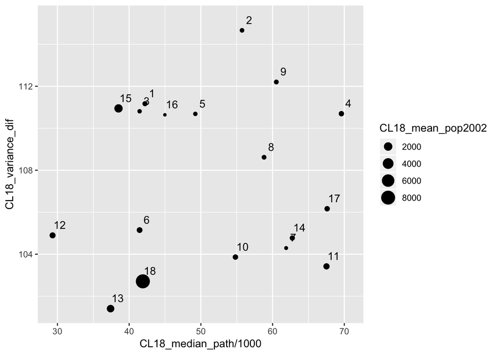

```r
clusters_18_metrics %>%
  ggplot(aes(x = CL18_median_path/1000, y = CL18_variance_dif))+
  # geom_smooth()+
  geom_point(aes(size = CL18_mean_pop2002))+
  geom_text(aes(x = CL18_median_path/1000+1, y = CL18_variance_dif + 0.5, label = clust_18))
```

Связи не вижу

Между динамикой населения и длиной пути тоже не видно ссвязи, но, кажется, тут есть какие-то группы?

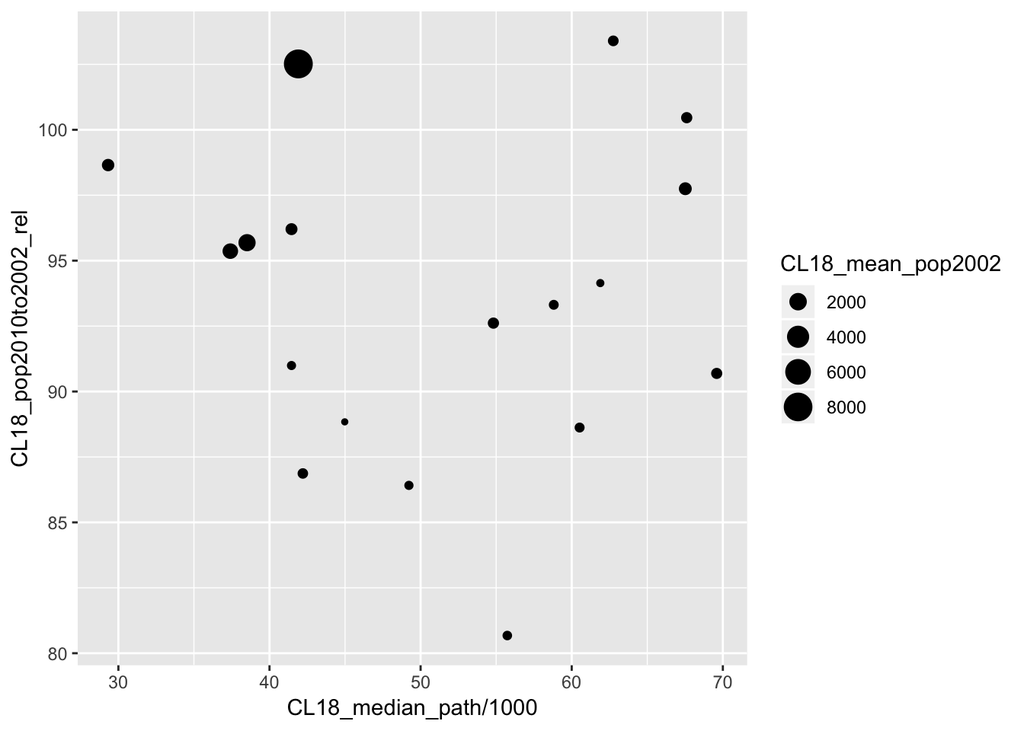

```r
clusters_18_metrics %>%
  ggplot(aes(x = CL18_median_path/1000, y = CL18_pop2010to2002_rel))+
  # geom_smooth()+
  geom_point(aes(size = CL18_mean_pop2002))
```

### 7. Различаются ли кластеры по показателям централизации и влияла ли централизация на темпы сжатия расселения?

В целом, картинки очень похожи. Хотя забавно, что кластеры с городами в итоге менее централизованы, чем кластеры вокруг районных центров.

*Централизация по близости*

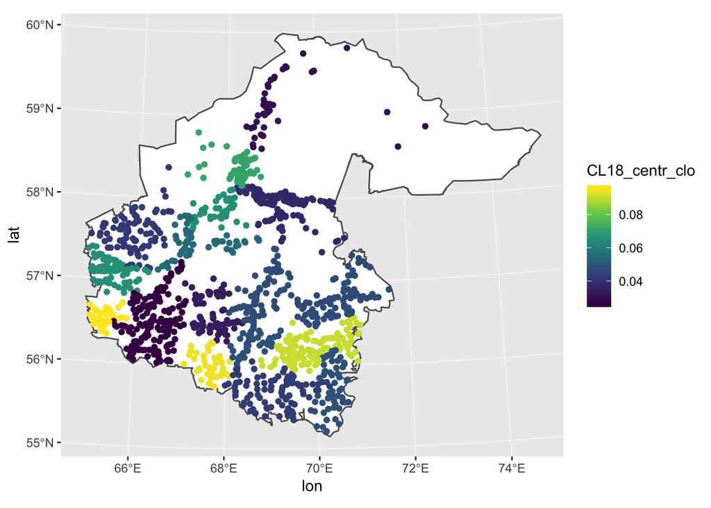

```r
ggplot()+
  geom_sf(data = st_as_sf(region), fill = "white")+
  geom_point(data = df, aes(x = lon, y = lat, col = CL18_centr_clo), inherit.aes = F)+
  scale_color_viridis_c()
```

*Централизация по посредничеству*

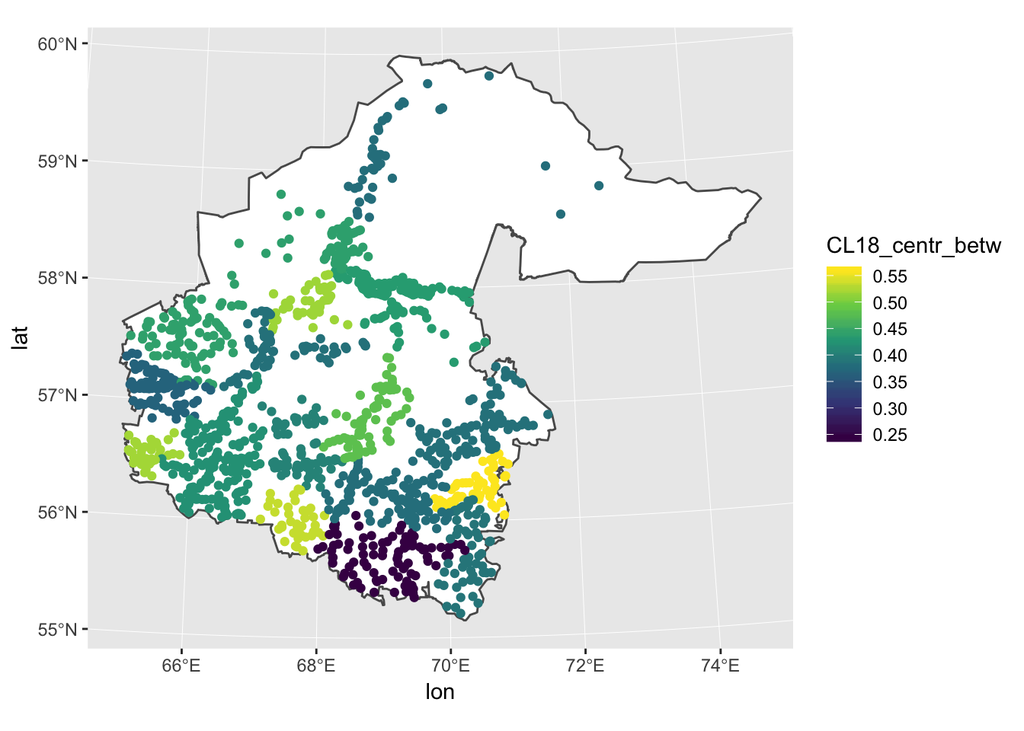

```r
ggplot()+
  geom_sf(data = st_as_sf(region), fill = "white")+
  geom_point(data = df, aes(x = lon, y = lat, col = CL18_centr_betw), inherit.aes = F)+
  scale_color_viridis_c()
```

Посмотрим на связь с темпами сжатия расселения

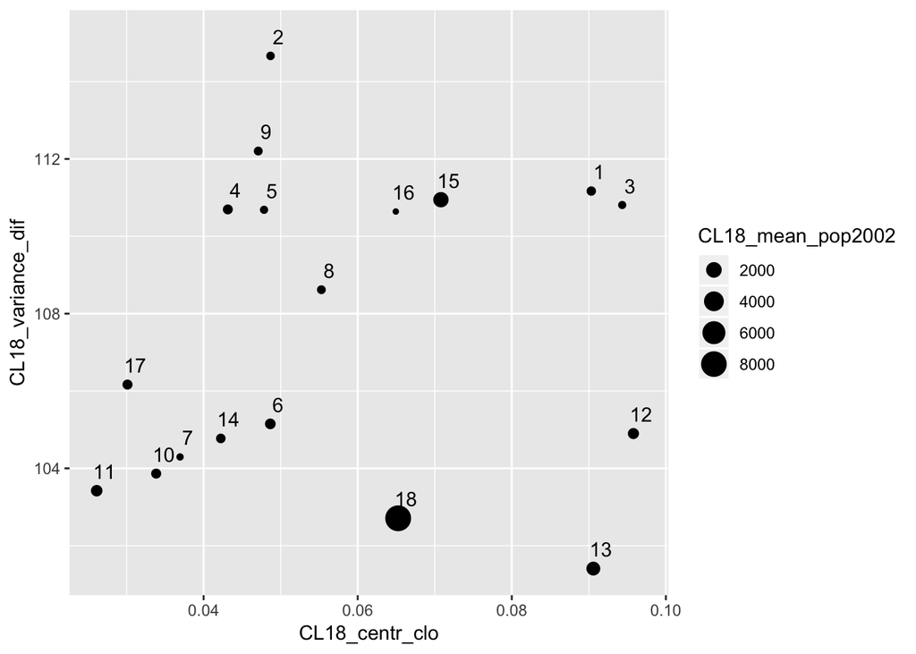

```r
clusters_18_metrics %>%
  ggplot(aes(x = CL18_centr_clo, y = CL18_variance_dif))+
  # geom_smooth()+
  geom_point(aes(size = CL18_mean_pop2002))+
  geom_text(aes(x = CL18_centr_clo+0.001, y = CL18_variance_dif + 0.5, label = clust_18))
```

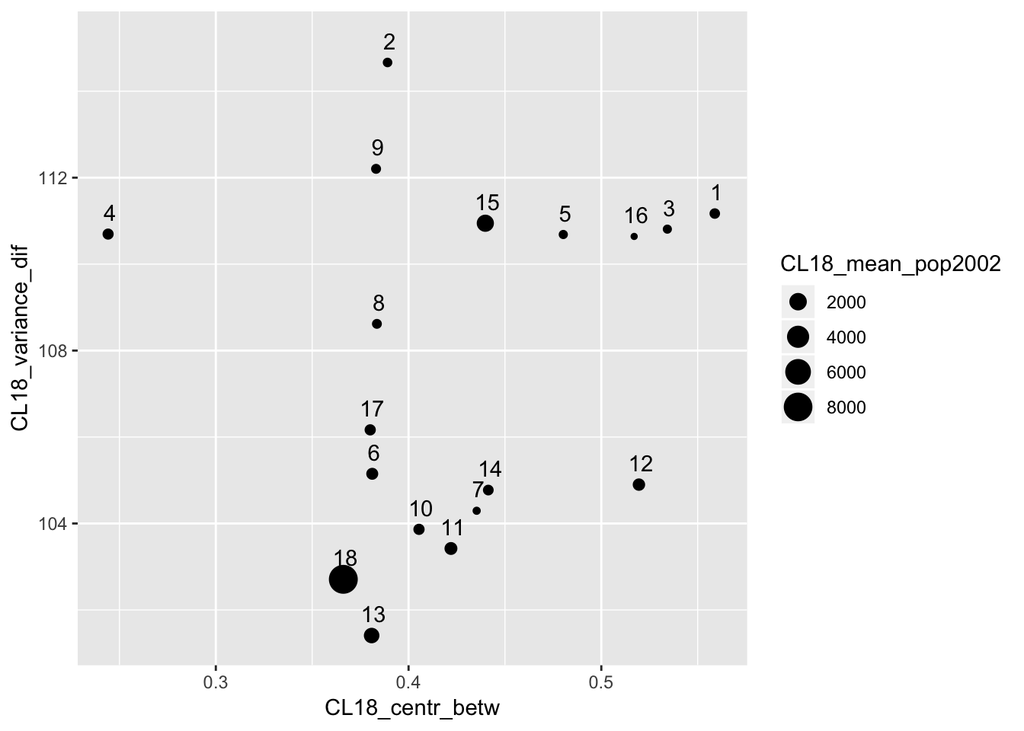

```r
clusters_18_metrics %>%
  ggplot(aes(x = CL18_centr_betw, y = CL18_variance_dif))+
  # geom_smooth()+
  geom_point(aes(size = CL18_mean_pop2002))+
  geom_text(aes(x = CL18_centr_betw+0.001, y = CL18_variance_dif + 0.5, label = clust_18))
```

В общем то, никакой особой связи я тут не вижу